# Music genre feature analysis

Tianyi Ma (Alex)

05.25.2024

# Music Genre Analysis

## Installing and loading common packages and libraries

```r
# install.packages('devtools')
```

```r
# install.packages('tidyverse', repos = "http://cran.us.r-project.org")
# devtools::install_github("hrbrmstr/hrbrthemes")
# install.packages('viridis')
```

```r
# install.packages("ggbeeswarm")
```

```r
# install.packages("fmsb")
```

```r
# install.packages('scales')
```

```r
# install.packages('Rpdb')
```

```r
library(tidyverse)
```

```r
library(ggplot2)
library(dplyr)
library(tidyr)
library(forcats)
library(hrbrthemes)
library(viridis)
library(lubridate)
library(ggbeeswarm)
library(fmsb)
library(scales)
library(stringr)
library(Rpdb)
options(warn=-1)
```

## Loading data csv

```r
df <- read.csv("data/music genre data.csv", header=TRUE)
```

```r
df <- df %>% drop_na()
head(df)
```

```
##             Artist.Name                            Track.Name instrumentalness
## 1            Bruno Mars That's What I Like (feat. Gucci Mane)         0.003910
## 2                Boston                          Hitch a Ride         0.004010
## 3         The Raincoats                    No Side to Fall In         0.000196
## 4                  Deno            Lingo (feat. J.I & Chunkz)         0.003910
## 5 Red Hot Chili Peppers     Nobody Weird Like Me - Remastered         0.016100
## 6           The Stooges     Search and Destroy - Iggy Pop Mix         0.006040
##   danceability energy loudness mode speechiness acousticness liveness valence
## 1        0.854  0.564   -4.964    1      0.0485     0.017100   0.0849  0.8990
## 2        0.382  0.814   -7.230    1      0.0406     0.001100   0.1010  0.5690
## 3        0.434  0.614   -8.334    1      0.0525     0.486000   0.3940  0.7870
## 4        0.853  0.597   -6.528    0      0.0555     0.021200   0.1220  0.5690
## 5        0.167  0.975   -4.279    1      0.2160     0.000169   0.1720  0.0918
## 6        0.235  0.977    0.878    1      0.1070     0.003530   0.1720  0.2410
##     tempo duration_in.min Popularity key time_signature     Genre Class
## 1 134.071           3.910         60   1              4    HipHop     5
## 2 116.454           4.196         54   3              4      Rock    10
## 3 147.681           1.828         35   6              4 Indie Alt     6
## 4 107.033           2.899         66  10              4    HipHop     5
## 5 199.060           3.833         53   2              4      Rock    10
## 6 152.952           3.469         53   6              4 Indie Alt     6
```

## 1. Visualize music features for each genre

For the first step of the analysis, I want to visualize the music features for each genre. The goal is to create a depiction of how each genre sound like by visualizing their properties, which are just the features. For example, I’d imagine that hip hop musics are very danceable, and metal musics are loud and have high energy.

First, we group songs from the same genre together.

```r
by_genre <- df %>% group_by(Genre)
```

Get the Alt music group to check that `group_by()` is working.

```r
alt <- by_genre %>% filter(Genre=="Alt")
head(alt)
```

```
## # A tibble: 6 × 18
## # Groups:   Genre [1]
##   Artist.Name     Track.Name instrumentalness danceability energy loudness  mode
##   <chr>           <chr>                 <dbl>        <dbl>  <dbl>    <dbl> <int>
## 1 Clairmont The … intres-ti…        0.0000289        0.796  0.441    -9.83     1
## 2 duendita        Open Eyes         0.105            0.341  0.47    -10.1      1
## 3 Brandon Jack &… four days         0.0564           0.516  0.948    -3.99     1
## 4 Veruca Salt     Seether           0.00153          0.612  0.86     -9.18     1
## 5 Nick Cave & Th… Deanna            0.00391          0.415  0.94     -4.87     1
## 6 BLAB            Casual Sex        0.0268           0.709  0.685    -7.57     1
## # ℹ 11 more variables: speechiness <dbl>, acousticness <dbl>, liveness <dbl>,
## #   valence <dbl>, tempo <dbl>, duration_in.min <dbl>, Popularity <dbl>,
## #   key <int>, time_signature <int>, Genre <chr>, Class <int>
```

Now we select the columns that we want to visualize. This is equivalent to select different music features to depict a genre. Here we include instrumentalness, danceability, energy, loudness, speechiness, acousticness, liveness and valence. I’ll also include their definitions and a dictionary that maps each term to its definition here.

### Definitions of music features

- **instrumentalness**: Predicts whether a track contains no vocals. “Ooh” and “aah” sounds are treated as instrumental in this context. Rap or spoken word tracks are clearly “vocal”. The closer the instrumentalness value is to 1.0, the greater likelihood the track contains no vocal content. Values above 0.5 are intended to represent instrumental tracks, but confidence is higher as the value approaches 1.0.
- **danceability**: Danceability describes how suitable a track is for dancing based on a combination of musical elements including tempo, rhythm stability, beat strength, and overall regularity. A value of 0.0 is least danceable and 1.0 is most danceable.
- **energy**: Energy is a measure from 0.0 to 1.0 and represents a perceptual measure of intensity and activity. Typically, energetic tracks feel fast, loud, and noisy. For example, death metal has high energy, while a Bach prelude scores low on the scale. Perceptual features contributing to this attribute include dynamic range, perceived loudness, timbre, onset rate, and general entropy.
- **loudness**: The overall loudness of a track in decibels (dB). Loudness values are averaged across the entire track and are useful for comparing relative loudness of tracks. Loudness is the quality of a sound that is the primary psychological correlate of physical strength (amplitude). Values typically range between -60 and 0 db.
- **speechiness**: Speechiness detects the presence of spoken words in a track. The more exclusively speech-like the recording (e.g. talk show, audio book, poetry), the closer to 1.0 the attribute value. Values above 0.66 describe tracks that are probably made entirely of spoken words. Values between 0.33 and 0.66 describe tracks that may contain both music and speech, either in sections or layered, including such cases as rap music. Values below 0.33 most likely represent music and other non-speech-like tracks.
- **acousticness**: A confidence measure from 0.0 to 1.0 of whether the track is acoustic. 1.0 represents high confidence the track is acoustic.
- **liveness**: Detects the presence of an audience in the recording. Higher liveness values represent an increased probability that the track was performed live. A value above 0.8 provides strong likelihood that the track is live.
- **valence**: A measure from 0.0 to 1.0 describing the musical positiveness conveyed by a track. Tracks with high valence sound more positive (e.g. happy, cheerful, euphoric), while tracks with low valence sound more negative (e.g. sad, depressed, angry).
- **tempo**: The overall estimated tempo of a track in beats per minute (BPM). In musical terminology, tempo is the speed or pace of a given piece and derives directly from the average beat duration.

First we get all column names of the dataset.

```r
col_names <- colnames(df)
col_names
```

```
##  [1] "Artist.Name"      "Track.Name"       "instrumentalness" "danceability"
##  [5] "energy"           "loudness"         "mode"             "speechiness"
##  [9] "acousticness"     "liveness"         "valence"          "tempo"
## [13] "duration_in.min"  "Popularity"       "key"              "time_signature"
## [17] "Genre"            "Class"
```

Then we select the columns that represents music features.

```r
feature_names <- c(col_names[3:6], col_names[8:12])
feature_names
```

```
## [1] "instrumentalness" "danceability"     "energy"           "loudness"
## [5] "speechiness"      "acousticness"     "liveness"         "valence"
## [9] "tempo"
```

Here we create a dictionary of the associated definition of each feature so that we can use this to aid visualization later.

```r
definitions_helper <- c("instrumentalness"="Predicts whether a track contains no vocals.",
  "danceability"="Describes how suitable a track is for dancing.",
  "energy"="Represents a perceptual measure of intensity and activity.",
  "loudness"="The overall loudness of a track in decibels (dB).",
  "speechiness"="Speechiness detects the presence of spoken words in a track.",
  "acousticness"="A confidence measure from 0.0 to 1.0 of whether the track is acoustic.",
  "liveness"="Detects the presence of an audience in the recording.",
  "valence"="A measure from 0.0 to 1.0 describing the musical positiveness conveyed by a track.",
  "tempo"="The overall estimated tempo of a track in beats per minute (BPM). "
  )
```

Finally, it’s time to apply visualization to each genre group. First, we define a function to normalize column values to between 0 and 1. This is applied to loudness and tempo, so that we can visualize them in the same scale as other features which all have range between 0 and 1.

Technically, the normalized values lose the actual measured values which has physical meanings like number of decibels and BPM, but since we use min max normalization they will still preserve the relative scale between songs’ feature values, so the distribution of values for those columns are still preserved and meaningful for our analysis.

```r
normalize_col <- function(tb, col) {
  col_min <- min(tb[, col])
  col_max <- max(tb[, col])
  col_range <- col_max - col_min
  tb_return <- tb
  tb_return[, col] <- (tb[, col] - col_min)/col_range
  return(tb_return)
}
```

To plot a graph for each group, we can apply the `group_map()` function to the groups `by_genre`. The syntax allow us to feed `.x` to the plotting function as an argument, where `x` is the table for the group without the column we group the dataset by, which in our case is `Genre`. For this reason, we need to feed `.y` to `group_map()` as the second argument so that we have access to the genre associated with each group.

This requires us to take in two argument, the first one will be the group table, and the second one is the Genre column that contains the group’s genre.

The violin plot function from ggplot2 takes in a categorical variable and one or more numerical variable(s). For this reason we need to convert music feature columns from wide format to long format. If you don’t know the different between long and wide format, [here is a short, nice guide for it.](https://www.statology.org/long-vs-wide-data/) Basically after converting we’ll get all the feature categories as values in one column and the associated values in another column. Since all data in a group is from the same genre, it won’t be a categorical variable within the group, and we’ll have one categorical column, namely the types of music features, and the associated numerical column. Then we’ll be ready to create the violin plot!

Creating a violin plot is just like creating other plots in ggplot2 and we just need to use the plotting function `geom_violin()`.

```r
plot_tb <- function(tb, group_by_column) {
  tb <- normalize_col(tb, 'loudness')
  tb <- normalize_col(tb, 'tempo')
  plot <- pivot_longer(tb, cols = feature_names)
  plot$name <- factor(plot$name, feature_names)
  tb_genre <- group_by_column$Genre
  p <- plot %>%
  ggplot( aes(x=name, y=value, fill=name, color=name)) +
    geom_violin(width=2.1, size=0.2) +
    scale_fill_viridis(discrete=TRUE) +
    scale_color_viridis(discrete=TRUE) +
    theme_ipsum() +
    theme(
      legend.position="none",
      axis.text.x = element_text(angle = 30, hjust=0.8),
      axis.title.x = element_text(size = 12, hjust=0.45)
    ) +
    xlab("Music Features") +
    ylab("Distribution") +
    ggtitle(paste("Value Distribution for Genre: ", tb_genre))

  p
}
```

The syntax of `group_map()` is `group_map(~f(**args))`. According to the docs:

- . or .x to refer to the subset of rows of .tbl for the given group. Aka. dependent variables of the group data.
- .y to refer to the key, a one row tibble with one column per grouping variable that identifies the group. Aka. the target variable(s) of the group data. If you grouped by more than one columns, there will be more than one columns in this table which are those columns you used to group by the dataset.

So here according to how we designed `plot_tb()`, the correct syntax is `group_map(~plot_tb(.x, .y))`.

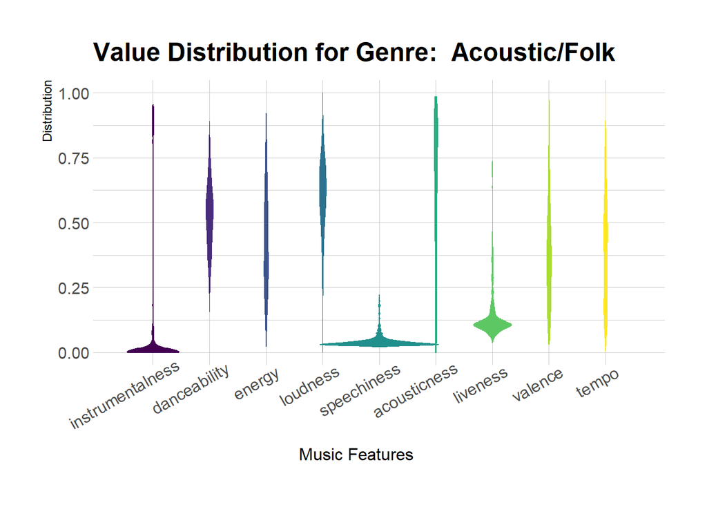

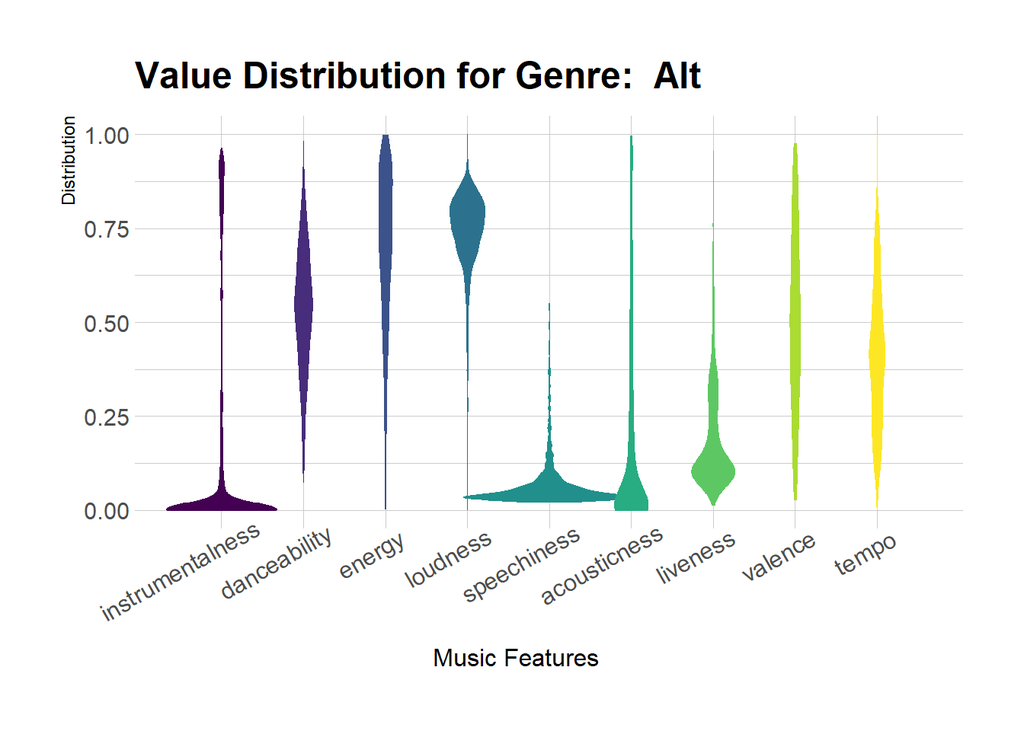

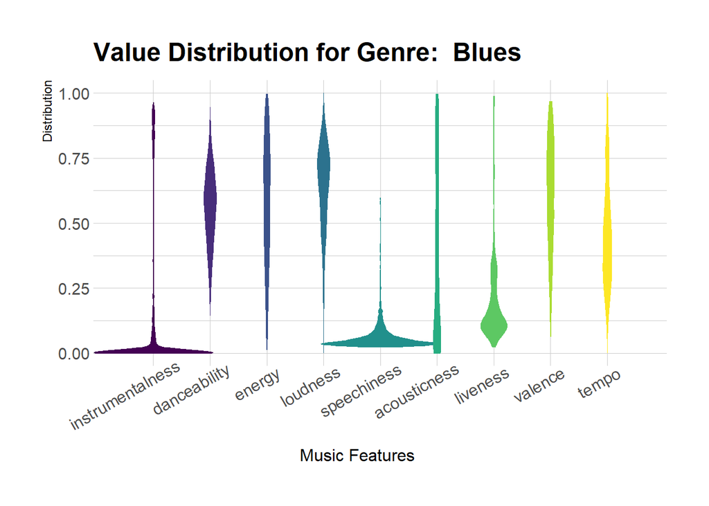

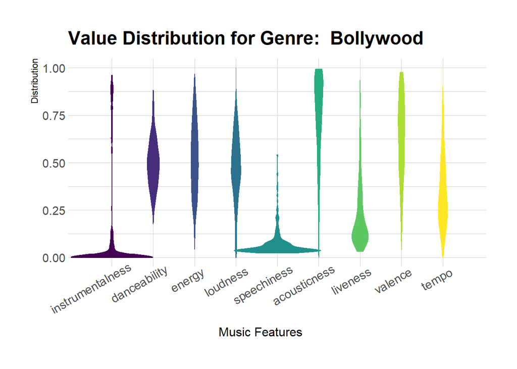

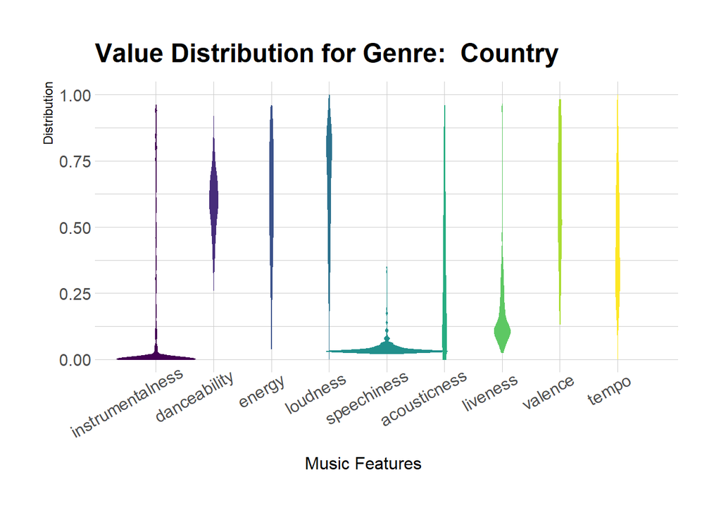

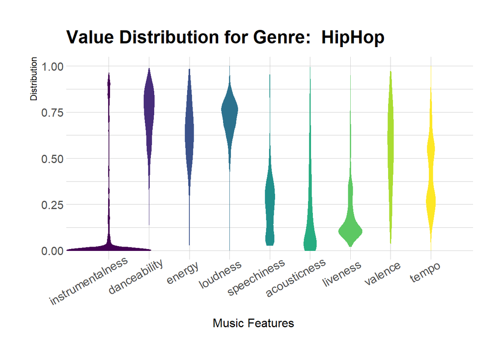

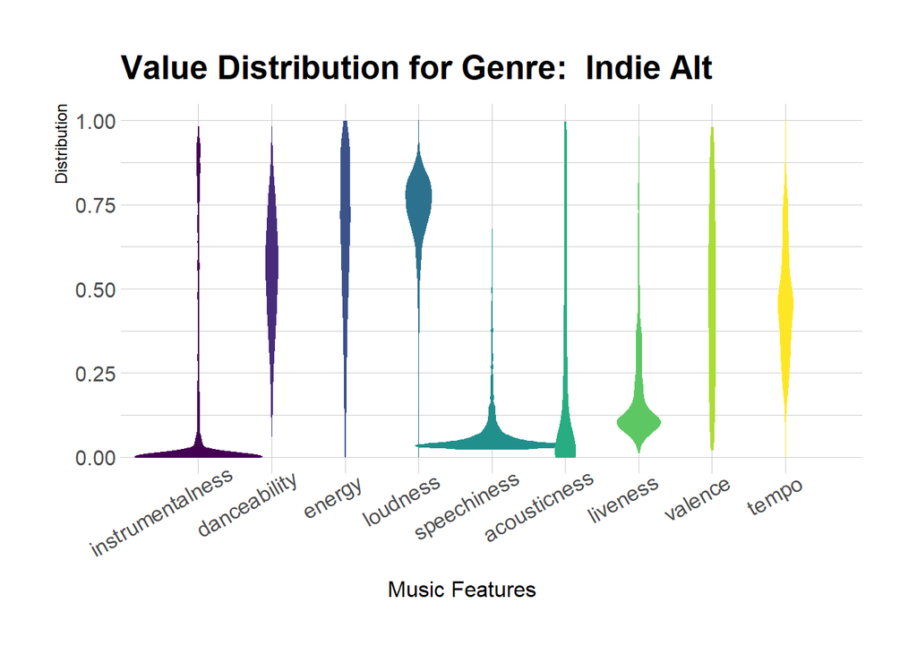

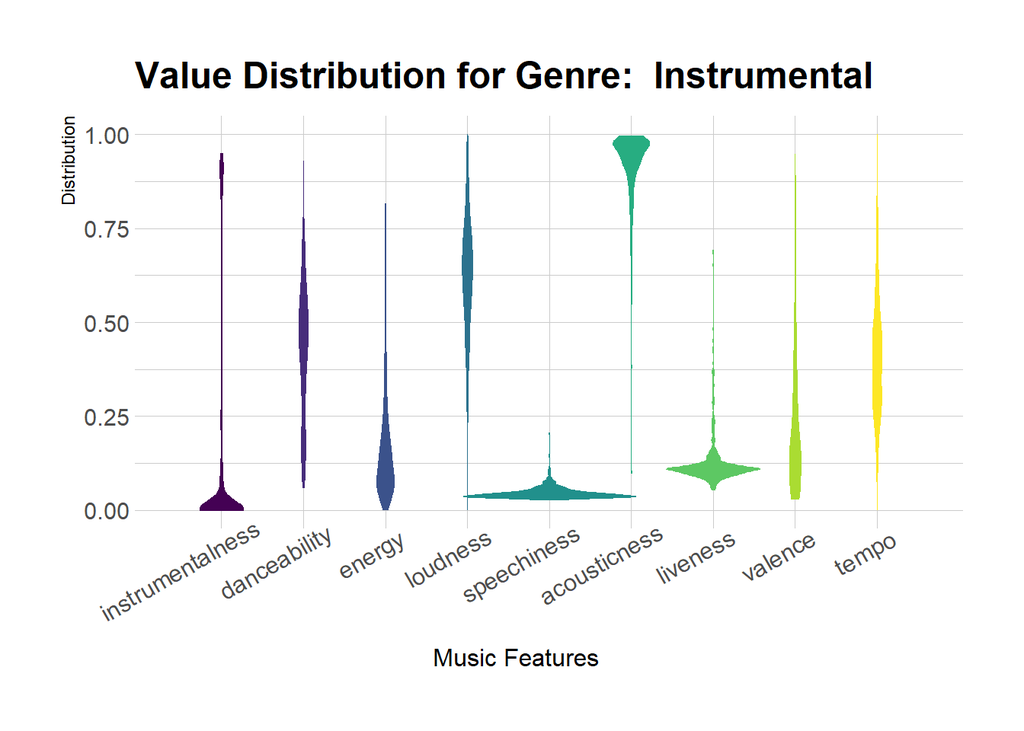

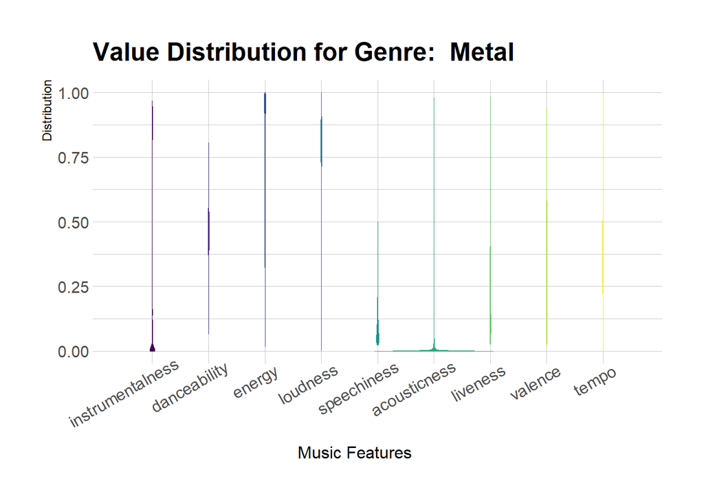

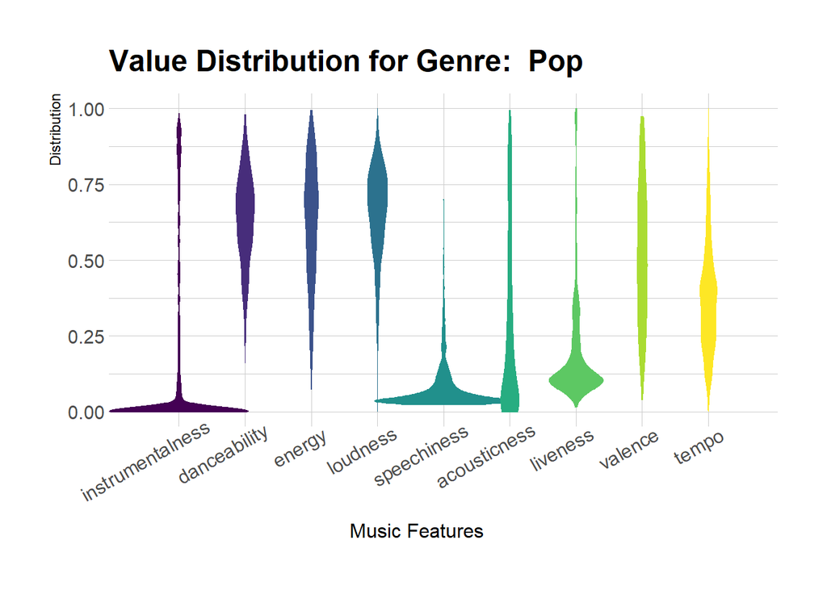

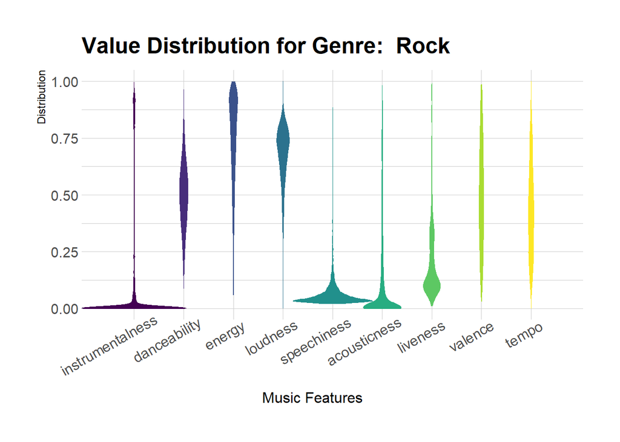

```r
by_genre %>% group_map(~plot_tb(.x, .y))
```

## 2. Visualize genre’s music feature using radar plot

After creating plots for all music features for each genre, I feel like it’s hard to tell the uniqueness between genres with these graphs. Yes, the distributions for each feature can be very different within each genre, but if you look at all of the graphs holistically it seems like some features are low/distributed similarly for all genres, so its “local minimality” doesn’t seem meaningful to me if that feature is low across genres. It seems like the graphs don’t do justice to depict each genre.

One problem here might be that using violin plot to show the distribution of the entire column doesn’t do justice to show the more nuanced differences in specific, important statistics such as median and quantiles. For example, in our graph, if median1 = 0.2 and median2 = 0.3, it’s hard to tell since the distribution might look very uniform, or the scale of the graph makes the difference in value not so distinguishable.

To solve this, I introduce radar plot. You can find some good illustration of it [here](https://r-graph-gallery.com/spider-or-radar-chart.html). Basically it forms a polygon on a radar background where each corner point is the numerical value of the category that the corner represent. This way, we zoom in on the specific statistical values of each music features and compare them in a micro scale to better depict the associated genre.

First, I’ll simply remove loudness and tempo from feature names because they are features with physical meanings and we can do it without them anyway.

```r
feature_names <- feature_names[! feature_names%in% c("loudness", "tempo")]
feature_names
```

```
## [1] "instrumentalness" "danceability"     "energy"           "speechiness"
## [5] "acousticness"     "liveness"         "valence"
```

For the data to be used to build the plot, I chose to visualize the median of each music feature values for each genre. Because these are continuous variables, it doesn’t make sense to use the mode. Because averages can be skewed because of the distribution, median is more robust to skewness and can better capture the profile of the genre.

To build the radar plot, we need to specify the range of the radar values, namely 1 and 0 in this case. Those need to be the first and second row of the dataset, and the third row should be the actual values you want to visualize.

Then we just need to call the `radarchart()` function and add some aesthetics. Remember to install and load the `fmsb` library!

```r
radar_plot_tb <- function(tb, group_by_column){
  tb_sub <- tb[,feature_names]
  medians <- c()
  for (i in 1:length(feature_names)){
    col_numeric <- as.numeric(as.character(unlist(tb_sub[,feature_names[i]])))
    medians[i] <- median(col_numeric)
  }
  range_max <- rep(1, length(feature_names))
  range_min <- rep(0, length(feature_names))

  data_tb <- data.frame(matrix(ncol = length(feature_names), nrow = 0))
  colnames(data_tb) <- feature_names
  tb_genre <- group_by_column$Genre

  data_tb[1,] <- range_max
  data_tb[2,] <- range_min
  data_tb[3,] <- medians

  radarchart( data_tb, axistype=1 ,

  #custom polygon
  pcol="#779ecc" , pfcol="#9fc0de" , plwd=3,

  #custom the grid
  cglcol="grey", cglty=1, axislabcol="grey", caxislabels=seq(0,1,0.1), cglwd=0.8,

  #custom labels
  vlcex=0.8, title=tb_genre
  )
}
```

The exciting bit - actually calling the function! You can definitely see that the depiction of each genre is much more pronounced using median values and radar plots.

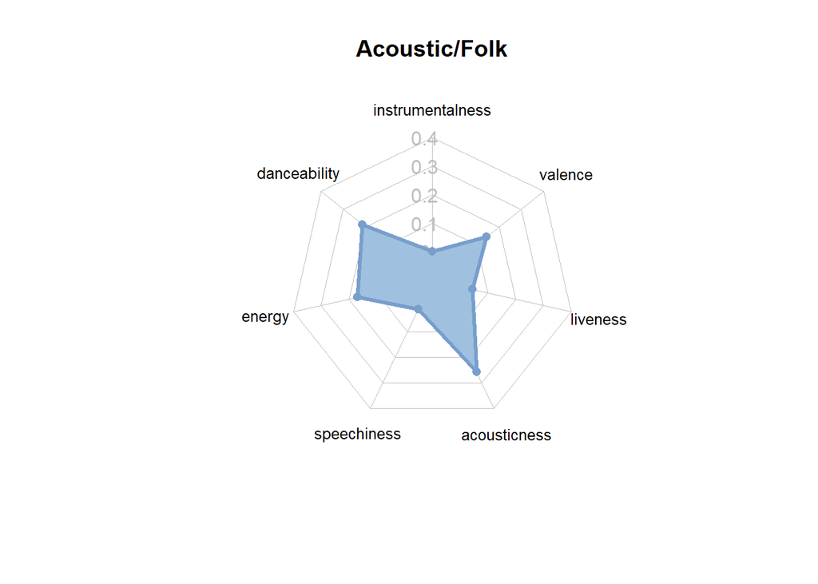

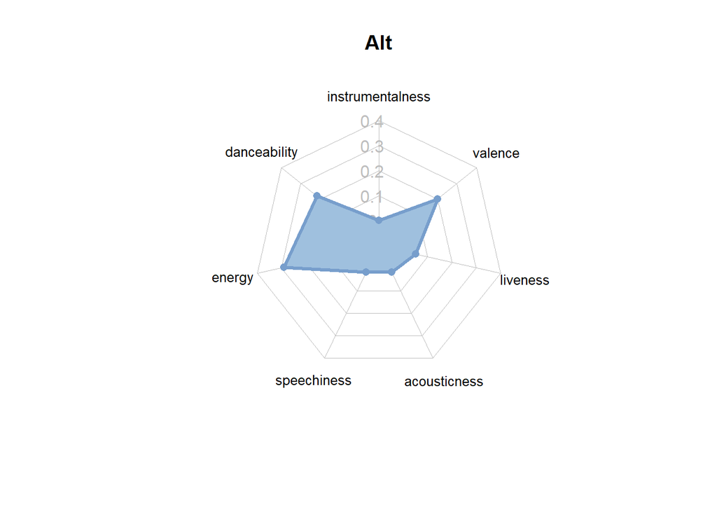

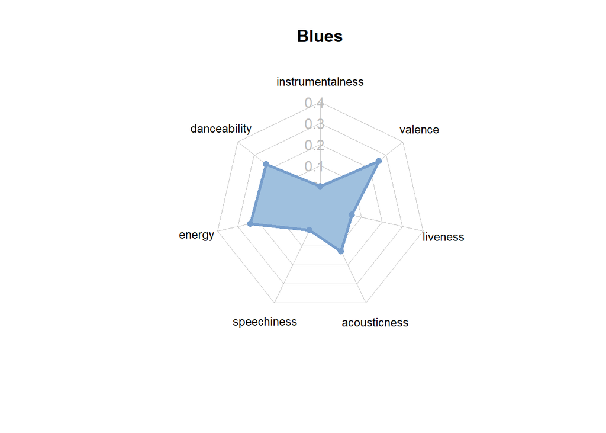

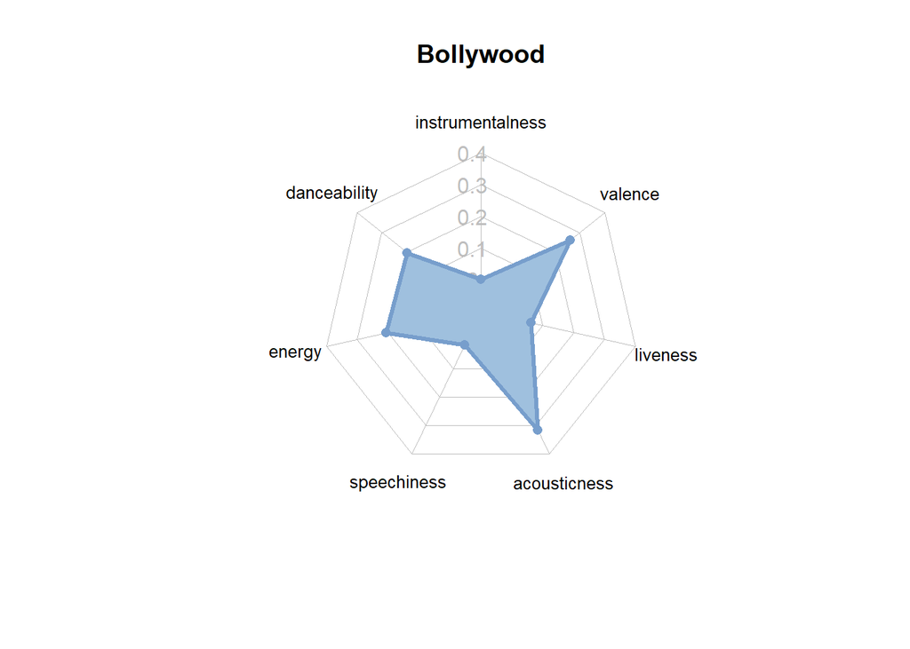

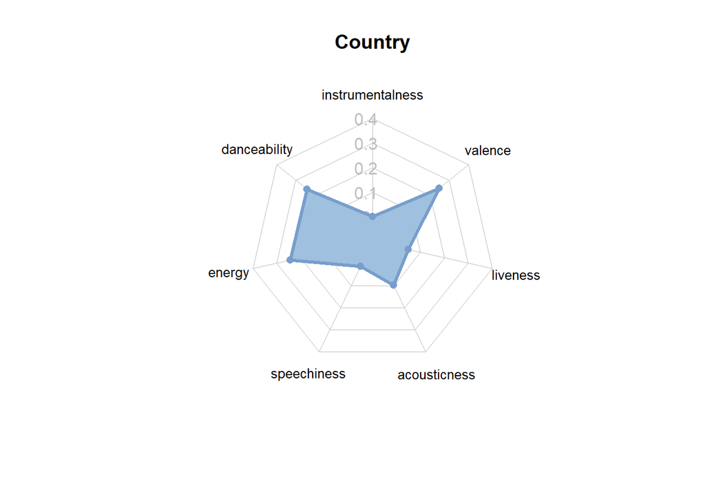

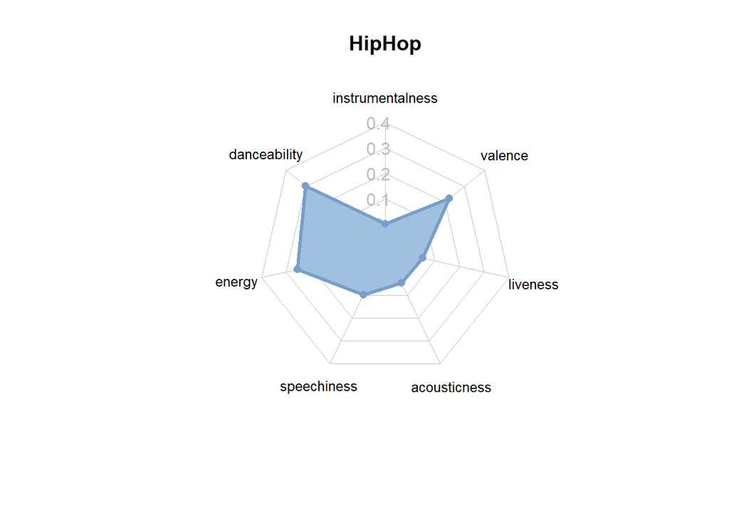

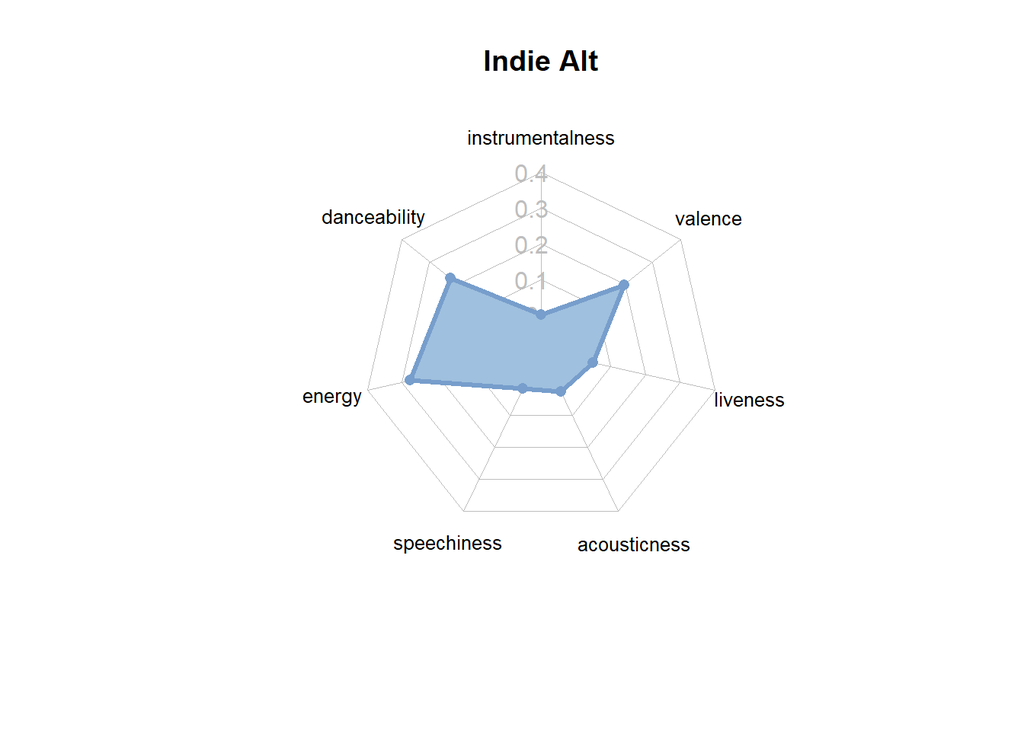

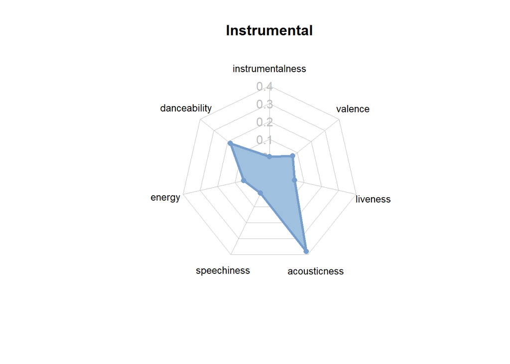

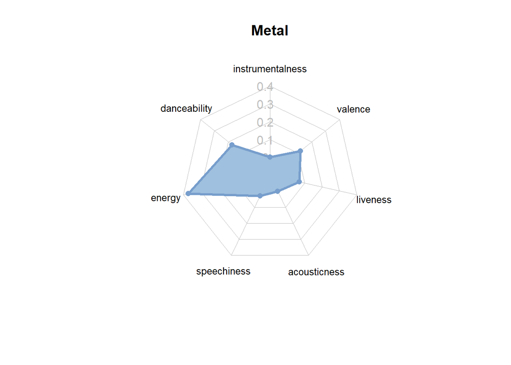

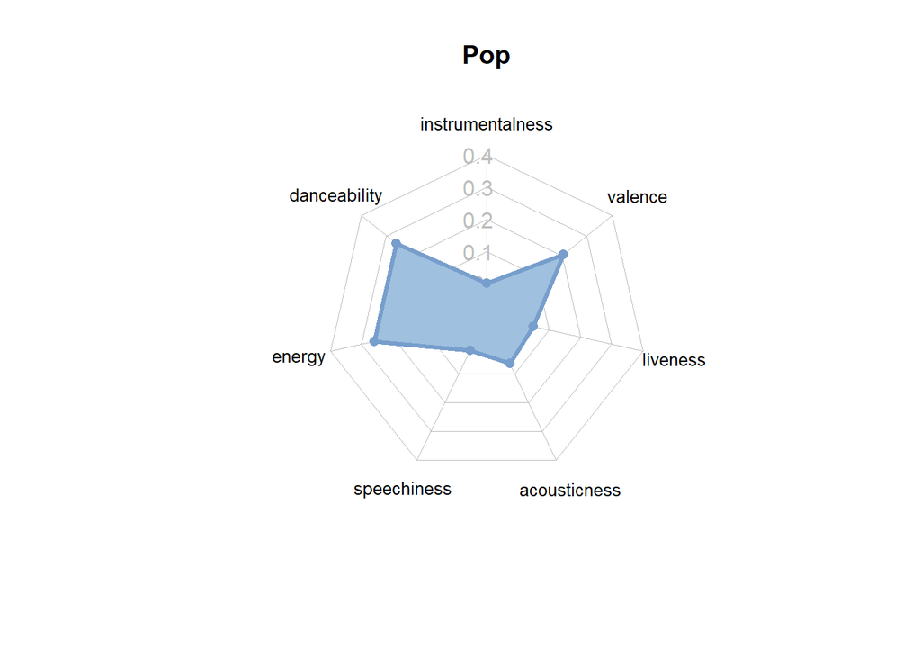

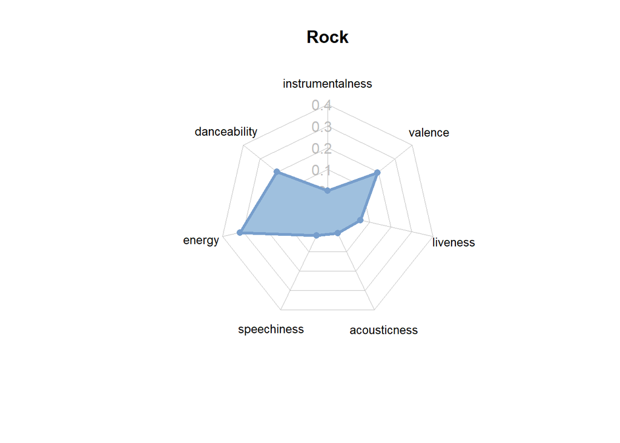

```r
by_genre %>% group_map(~radar_plot_tb(.x, .y))
```

## 3. Visualize and compare each music feature across genres.

Another nice way to uniquely depict each genre is to visualize and compare each music feature across genres.

This is much easier to do than the previous two attempts because we don’t need to wrangle the data before feeding them into a plotting function. The format of the data is already correct. We just need a for loop to create the graph for each feature column. Let’s create the plotting function for a specific column.

We used violin graph last time and I love violin plot because it not only show you the quantiles but also roughly the actual distributions. So a feature could have multiple peak values and it would show in a violin plot but not a box plot. However, compare to histogram, violin plot could also smooth out the minimal points and makes it look like there are still some values on the low points even if there is none. Which is why I’ll overlay the violin plot with a jitter points plot to allow a more robust understanding of the value distributions. To avoid clustering the plots with too much data (we do have a relatively big dataset if we’re actually plotting every point), I sampled 500 rows from the dataset and used that to plot the jitter points plot.

```r
plot_column <- function(tb, numerical_column) {
  genre <- tb$Genre

  if (numerical_column == 'loudness') {
    value <- normalize_loudness(tb)[,numerical_column]
  } else if (numerical_column == 'tempo') {
    value <- normalize_loudness(tb)[,numerical_column]
  } else {
    value <- tb[,numerical_column]
  }

  tb_sample <- tb[sample(nrow(df), 500), ]
  tb_genre <- tb_sample$Genre
  tb_value <- tb_sample[,numerical_column]

  p <- ggplot(data=tb, aes(x=genre, y=value, fill=genre, color=genre)) +
      geom_violin(width=2.1, size=0.2) +
      geom_point(data=tb_sample, aes(x=tb_genre, y=tb_value, fill=tb_genre),
                 position = position_jitter(seed = 1, width = 0.2), color='grey', alpha=0.65) +
      scale_fill_viridis(discrete=TRUE) +
      scale_color_viridis(discrete=TRUE) +
      theme_ipsum() +
      theme(
        legend.position="none",
        axis.text.x = element_text(angle = 30, hjust=0.8),
        axis.title.x = element_text(size = 12, hjust=0.45)
      ) +
      xlab("Music Genres") +
      ylab("Distribution") +
      labs(caption=definitions_helper[numerical_column],
           title=paste("Genre Value Distribution for Value: ", numerical_column))

  print(p)
}
```

This is the for loop that will plot each feature across all genres.

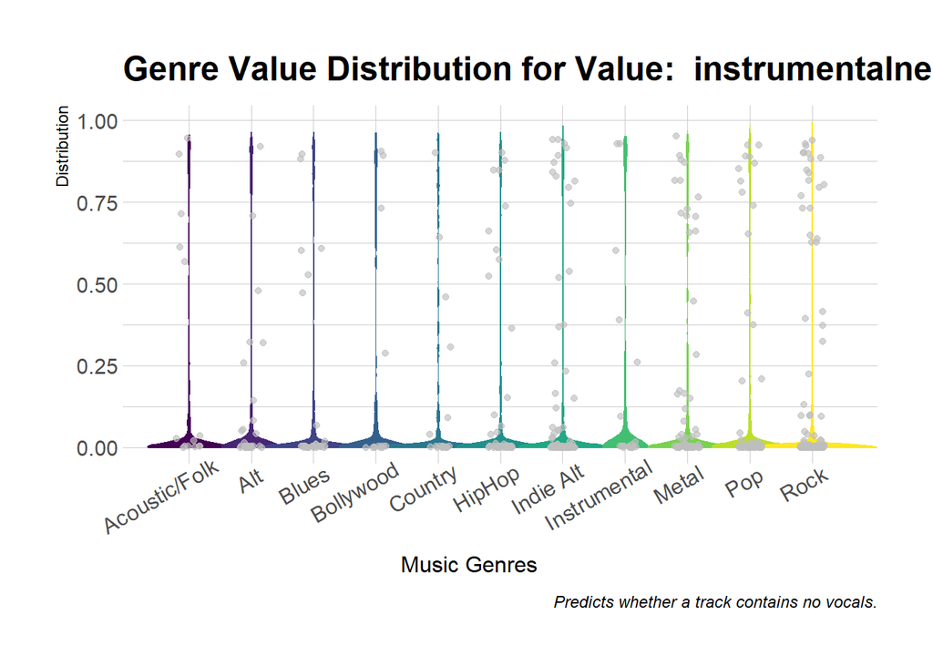

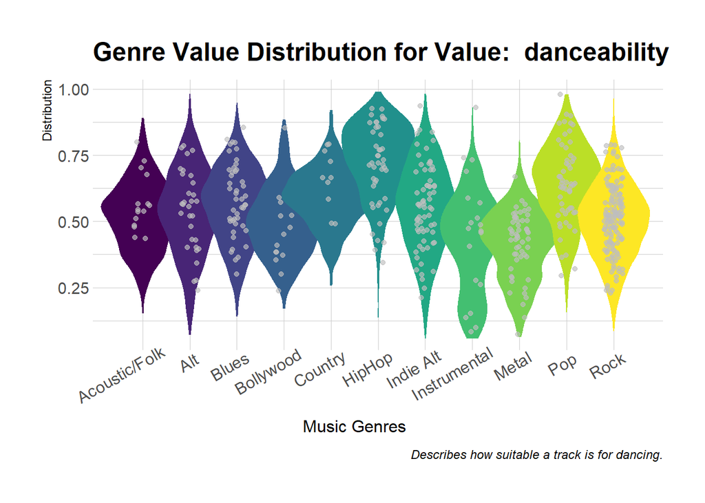

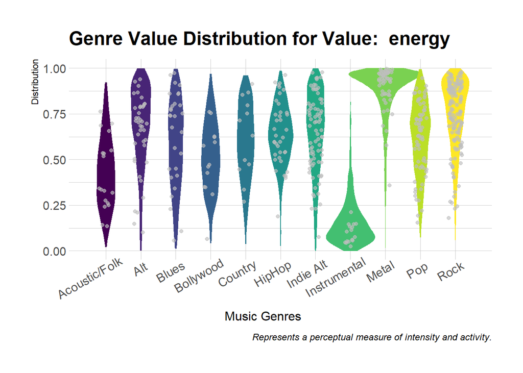

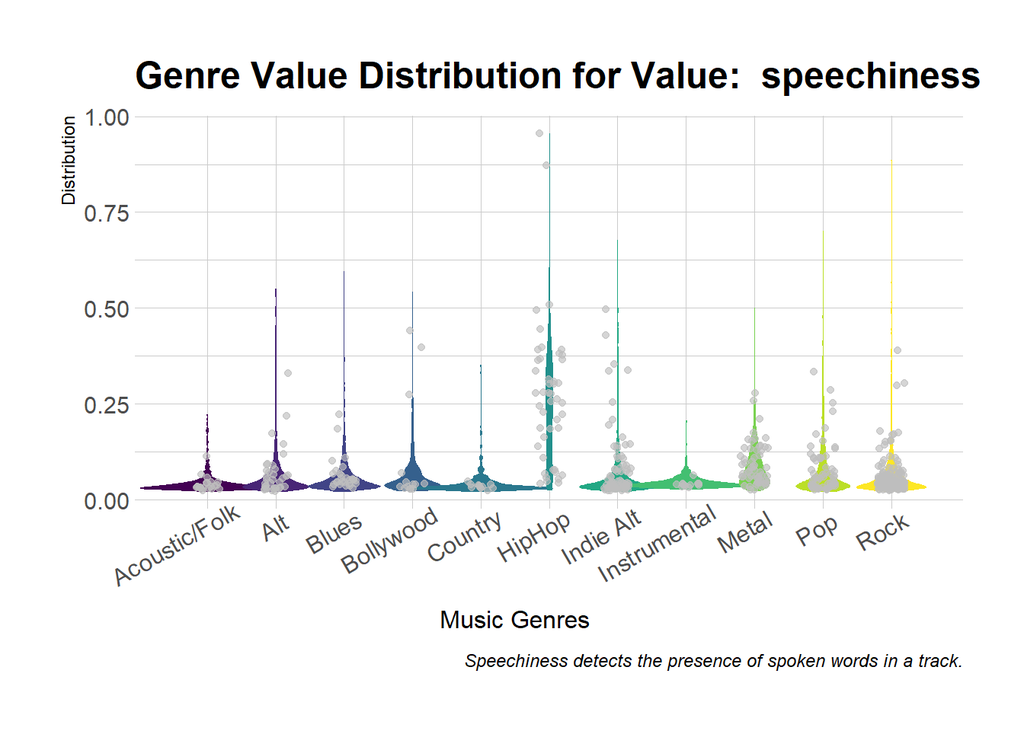

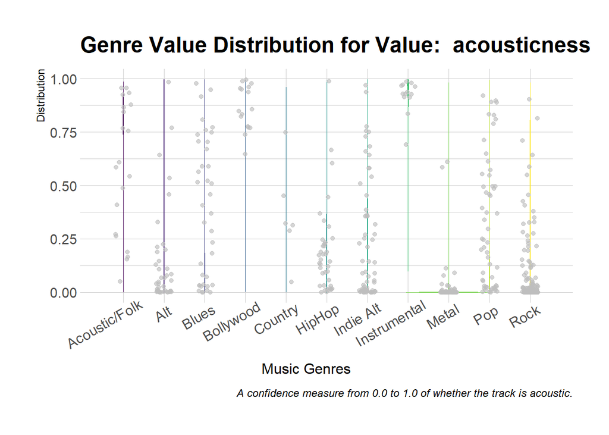

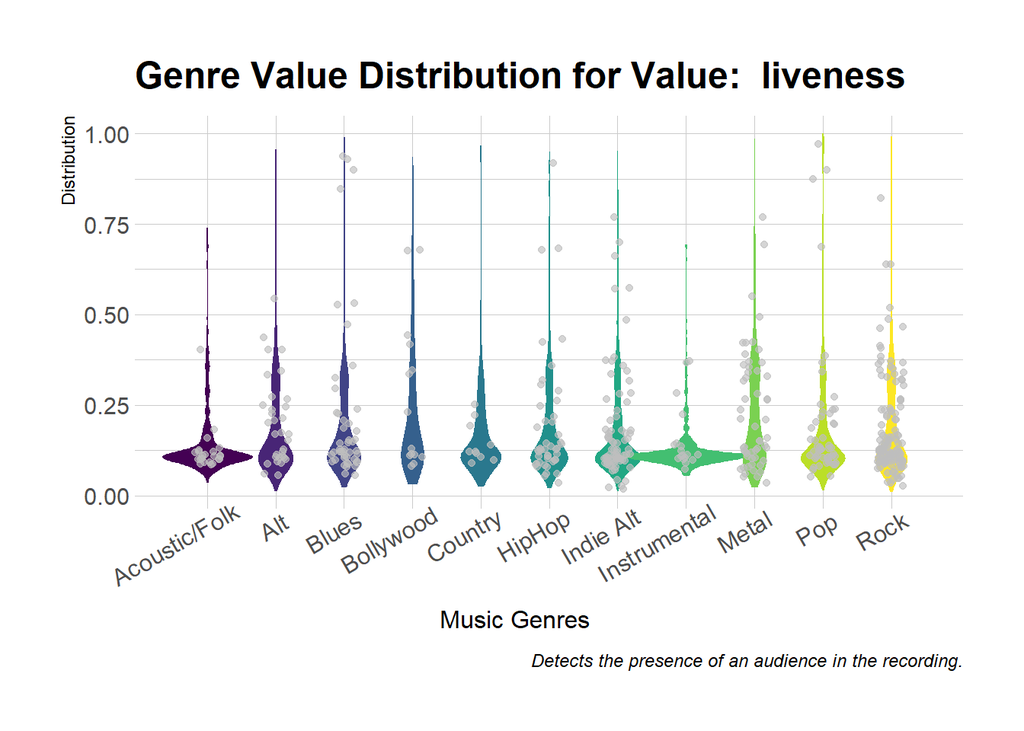

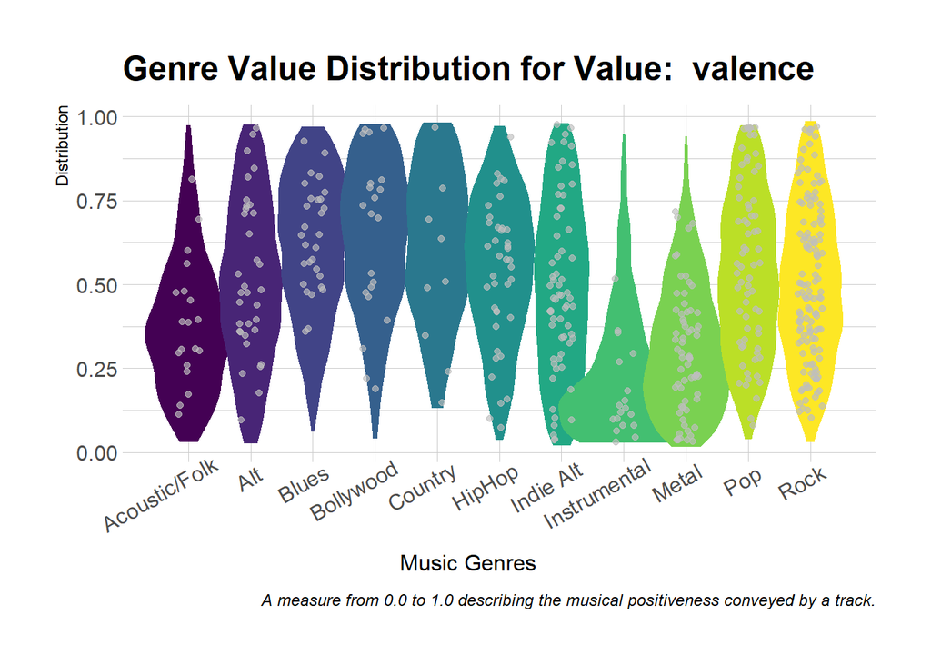

```r
for (col in feature_names) {
  plot_column(df, col)
}
```

## 4. Visualizing popularity distribution for each genre

It’s very important for music businesses to get more insights on the popularity of songs. Let’s try to visualize popularities in different ways to gain more insights into this attribute.

Programmatically, we define the breaks and labels, and then use `cut()` to segment the data and then return a new column that tag each popularity measure with one of the bin labels, which we call `bins`.

```r
breaks <- seq(0, 100, by=10)
labels <- c()
for (i in 1:10) {
  labels[i] <- paste(as.character(10*(i-1)), " - ", as.character(10*i))
}
print(labels)
```

```
##  [1] "0  -  10"   "10  -  20"  "20  -  30"  "30  -  40"  "40  -  50"
##  [6] "50  -  60"  "60  -  70"  "70  -  80"  "80  -  90"  "90  -  100"
```

```r
bins <- cut(df$Popularity, breaks = breaks, labels = labels)
bins[1:10]
```

```
##  [1] 50  -  60 50  -  60 30  -  40 60  -  70 50  -  60 50  -  60 40  -  50
##  [8] 50  -  60 20  -  30 10  -  20
## 10 Levels: 0  -  10 10  -  20 20  -  30 30  -  40 40  -  50 ... 90  -  100
```

After we get the bins column, we need to count the unique values, namely what are the unique values, and how many times each value appears in the column. To achieve that, I convert `table(bins)` to a dataframe with two columns: `bins` and `Freq` where `bins` are the unique values and `Freq` is the count of each unique value.

```r
unique_value_freq <- as.data.frame(table(bins))
unique_value_freq
```

```
##          bins Freq
## 1    0  -  10  456
## 2   10  -  20  744
## 3   20  -  30 1820
## 4   30  -  40 3449
## 5   40  -  50 4246
## 6   50  -  60 2917
## 7   60  -  70 1839
## 8   70  -  80 1078
## 9   80  -  90  286
## 10 90  -  100   41
```

We can than easily plot the popularity distribution with this dataframe, using `geom_segment()` to create a vertical line representing each value and `geom_point()` to add a dot to the end of each line so that the tip is emphasized. This kind of graph is called a lolipop graph due to the appearance resembling lolippops, and I especially like this representation for comparing values because it makes it very clear the scale of each value and easy to see which values are larger or smaller.

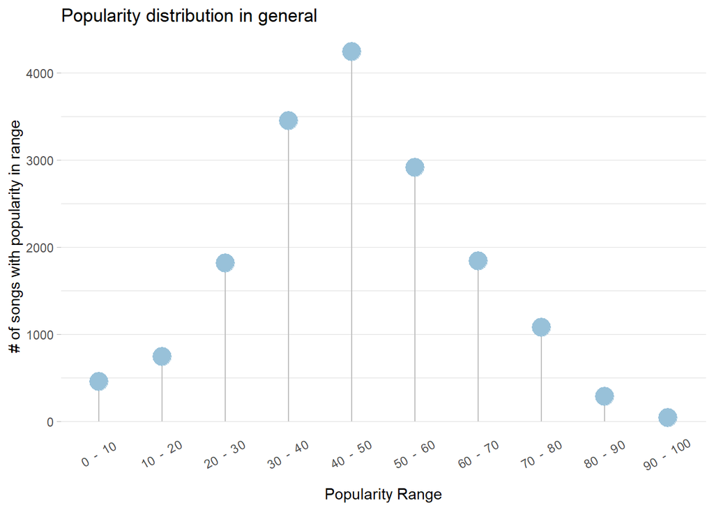

```r
ggplot(unique_value_freq, aes(x=bins, y=Freq)) +
  geom_segment( aes(x=bins, xend=bins, y=0, yend=Freq), color="grey") +
  geom_point( color="#98c1d9", size=6) +
  theme_light() +
  theme(
    panel.grid.major.x = element_blank(),
    panel.border = element_blank(),
    axis.ticks.x = element_blank(),
    axis.text.x = element_text(angle = 30, hjust=0.6),
  ) +
  xlab("Popularity Range") +
  ylab("# of songs with popularity in range")  +
  labs(title="Popularity distribution in general")
```

Our visualization was successful, but note that this is the distribution for all songs, without grouping by genres. I’m curious about how the distribution of popularity values are different from the general distribution. To do this, we create a 2 categorical variable lolipop graph for each genre.

First, we need to scale down the general distribution somehow. If you look at the values in each bin, they are garanteed to be much higher than value of each bin for a specific genre, just because the sheer volumn of data is larger than that of one genre. Naturally we can just multiply each bin value with (number of rows in genre group)/(total number of rows), but that’s a bit artificial and doesn’t make physical sense. Here, I chose to sample (number of rows in genre group) rows from the entire dataset and this subset can serve as a sensible representation of the entire dataset.

To do that, we construct a function called `get_undersampled_unique_value_freq()` to sample the dataset and calculate bins.

```r
get_undersampled_unique_value_freq <- function(df, group_nrow) {
  df_sample <- df[sample(nrow(df), group_nrow), ]
  bins <- cut(df_sample$Popularity, breaks = breaks, labels = labels)
  unique_value_freq <- as.data.frame(table(bins))
  return(unique_value_freq)
}
```

Then we just create the popularity bin values of the genre and attach it to the general undersampled bin values, so that we can use that dataframe as data for the plot. The syntax is kind of the same as the general distribution plot. I also used a red orange color for individual genre bin values so that it naturally grabs attention and draws people’s eye to the genre value but still with an available reference to the general distribution bin value in blue.

```r
lolipop_plot_2groups <- function(group_tb, group_by_column) {
  unique_value_freq_undersampled <- get_undersampled_unique_value_freq(df, nrow(group_tb))
  group_bins <- cut(group_tb$Popularity, breaks = breaks, labels = labels)
  group_unique_value_freq <- as.data.frame(table(group_bins))
  unique_value_freq_undersampled$Freq_group <- group_unique_value_freq$Freq

  tb_genre <- group_by_column$Genre

  ggplot(unique_value_freq_undersampled) +
  geom_segment( aes(x=bins, xend=bins, y=Freq, yend=Freq_group), color="grey") +
  geom_point( aes(x=bins, y=Freq), color="#9fc0de", size=5, alpha=0.65 ) +
  geom_point( aes(x=bins, y=Freq_group), color="#FF4433", size=5, alpha=0.5 ) +
  theme_ipsum() +
  theme(
    panel.grid.major.x = element_blank(),
    panel.border = element_blank(),
    axis.ticks.x = element_blank(),
    axis.text.x = element_text(angle = 30, hjust=0.6),
  ) +
  xlab("Popularity Range") +
  ylab("# of songs with popularity in range") +
  ggtitle(paste("Popularity distribution in general vs. ", tb_genre))
}
```